# Loan analysis by Xin Pang

**Background** Prosper.com is a peer-to-peer lending website privoding individuals with services to borrow money or invest in personal loans. According to [Wikipedia](https://en.wikipedia.org/wiki/Prosper_Marketplace) this company used two different ways to calculate loan interest rates. From 2006 to 2009 the loan interest rate was determined by borrowers and lenders in a bidding system. Afterwards the rate is predefined by Prosper based on a formula evaluating each prospective borrower’s credit risk. The dataset to be analyzed contains users’ loan details from November 2005 to March 2014, including 113937 loan records with 81 variables.

## Overview

We want to know the type of each column, wether they are numeric or factor, such that we can select a few of them for analysis. Due to the large number of variables in the dataframe, here I only show the type of first 10 attributes. From the result we can see there are both factor variables and numerical variables.

```
## $ListingKey
## [1] "factor"
##
## $ListingNumber
## [1] "integer"
##
## $ListingCreationDate
## [1] "factor"
##
## $CreditGrade
## [1] "factor"
##
## $Term
## [1] "integer"
##
## $LoanStatus
## [1] "factor"
##
## $ClosedDate
## [1] "factor"
##
## $BorrowerAPR
## [1] "numeric"
##
## $BorrowerRate
## [1] "numeric"
##
## $LenderYield
## [1] "numeric"
```

The main features of interest are the following:

- Term: The length of the loan expressed in months. (integer->factor)
- Loan status: The current status of the loan. (factor)
- Borrower rate: The borrower’s interest rate for this loan. (numeric)
- Listing category: The category of the listing that the borrower selected when posting their listing. (integer->factor)
- Income range: The income range of the borrower at the time the listing was created. (factor)
- Loan original amount: The origination amount of the loan. (integer)
- Loan origination date: The origination date of the loan. (factor->date)
- Percent funded: Percent the listing was funded. (numeric)
- Recommendations: Number of recommendations the borrower had at the time the listing was created. (integer)
- Investors: The number of investors that funded the loan. (integer)

There are a few variables requiring a conversion for proper types.

- Term: contains 3 values and can be changed to a factor.
- Listing category: they are actually coded into numbers, each number representing one category, thus it should be factor instead of integer.
- Loan origination date: should be in date format.

Below processes the column type conversion and change the factor level of Listing Category. Afterwards we look at the summary of all variables of interest. Almost all the values are in normal range, only in investors we see loans funded by 1189 members to the maximum, which is an unusual thing.

```
##  Term                       LoanStatus     BorrowerRate
##  12: 1614   Current              :56576   Min.   :0.0000
##  36:87778   Completed            :38074   1st Qu.:0.1340
##  60:24545   Chargedoff           :11992   Median :0.1840
##             Defaulted            : 5018   Mean   :0.1928
##             Past Due (1-15 days) :  806   3rd Qu.:0.2500
##             Past Due (31-60 days):  363   Max.   :0.4975
##             (Other)              : 1108
##            ListingCategory          IncomeRange    LoanOriginalAmount
##  Debt Consolidation:58308   $25,000-49,999:32192   Min.   : 1000
##  Not Available     :16965   $50,000-74,999:31050   1st Qu.: 4000
##  Other             :10494   $100,000+     :17337   Median : 6500
##  Home Improvement  : 7433   $75,000-99,999:16916   Mean   : 8337
##  Business          : 7189   Not displayed : 7741   3rd Qu.:12000
##  Auto              : 2572   $1-24,999     : 7274   Max.   :35000
##  (Other)           :10976   (Other)       : 1427
##  LoanOriginationDate           PercentFunded    Recommendations
##  Min.   :2005-11-15 00:00:00   Min.   :0.7000   Min.   : 0.00000
##  1st Qu.:2008-10-02 00:00:00   1st Qu.:1.0000   1st Qu.: 0.00000
##  Median :2012-06-26 00:00:00   Median :1.0000   Median : 0.00000
##  Mean   :2011-07-21 03:44:57   Mean   :0.9986   Mean   : 0.04803
##  3rd Qu.:2013-09-18 00:00:00   3rd Qu.:1.0000   3rd Qu.: 0.00000
##  Max.   :2014-03-12 00:00:00   Max.   :1.0125   Max.   :39.00000
##
##    Investors
##  Min.   :   1.00
##  1st Qu.:   2.00
##  Median :  44.00
##  Mean   :  80.48
##  3rd Qu.: 115.00
##  Max.   :1189.00
##
```

#### Is the number of loans affected by choices of different interest rate models?

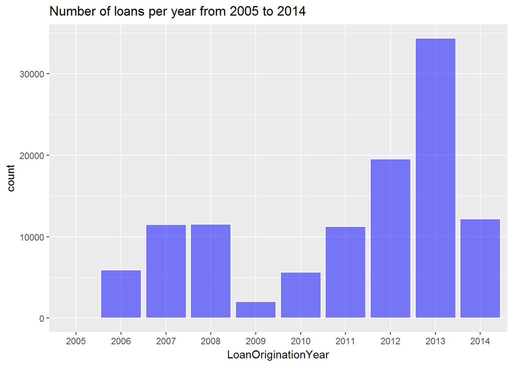

#### What is the most chosen term of loans?

The plot below shows most people have chosen loans of longer terms. 36 months of loans are chosen by most of the people.

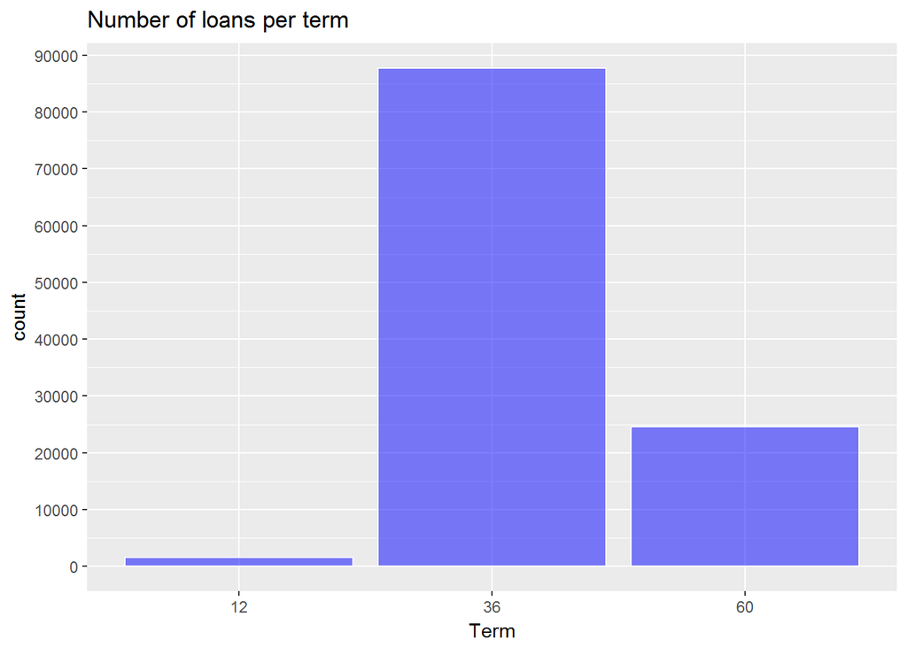

This plot shows people with income 25000 to 75000 have the most number of loans.

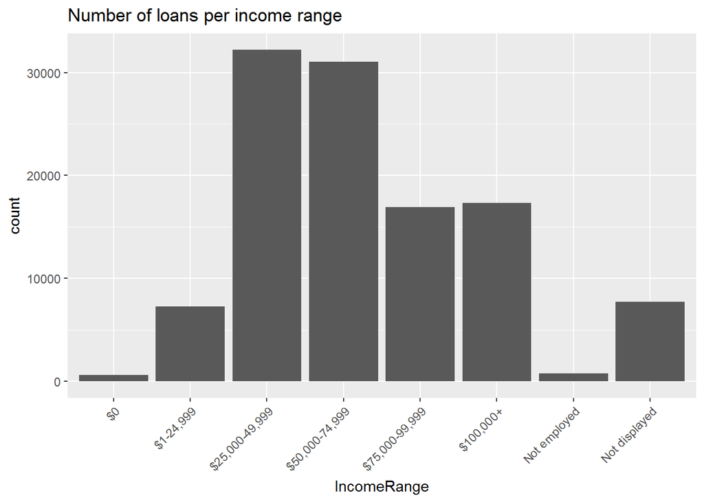

The plot below shows different purposes of loans. The category of debt-consolidation has most number of loans.

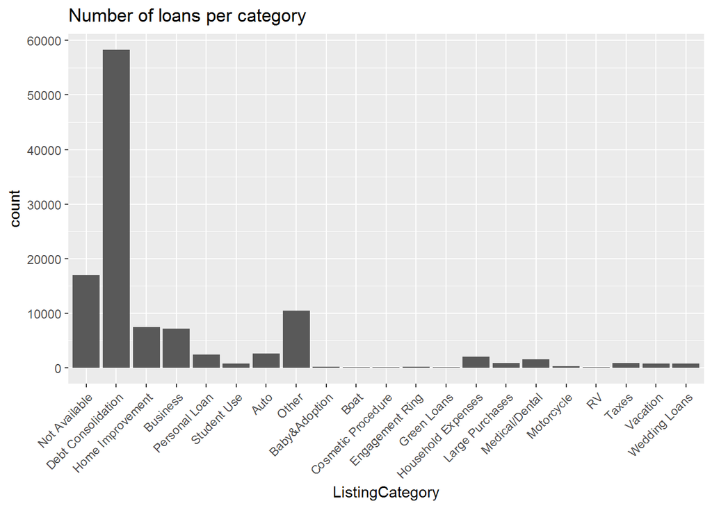

Next we generate a histogram for borrower interest rate with bin width 0.01. Overall, the most frequent interest rate is around 0.15, with frequency decreasing along each side. It is worth noticing in the range of 0.32-0.33, that there is another peak. This might be some default value determined by the system.

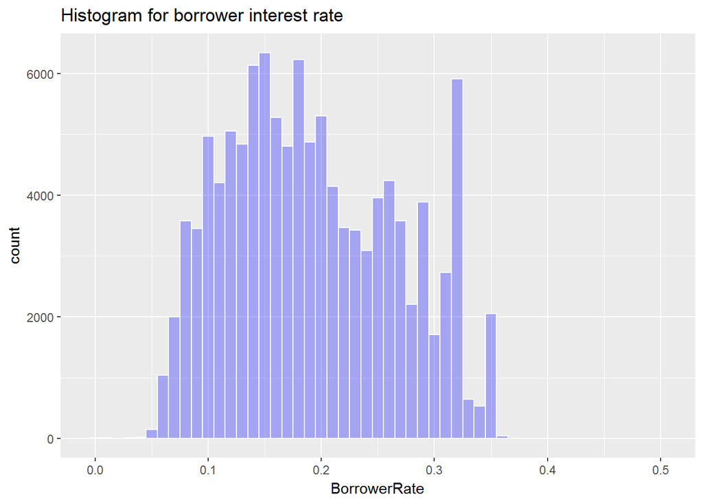

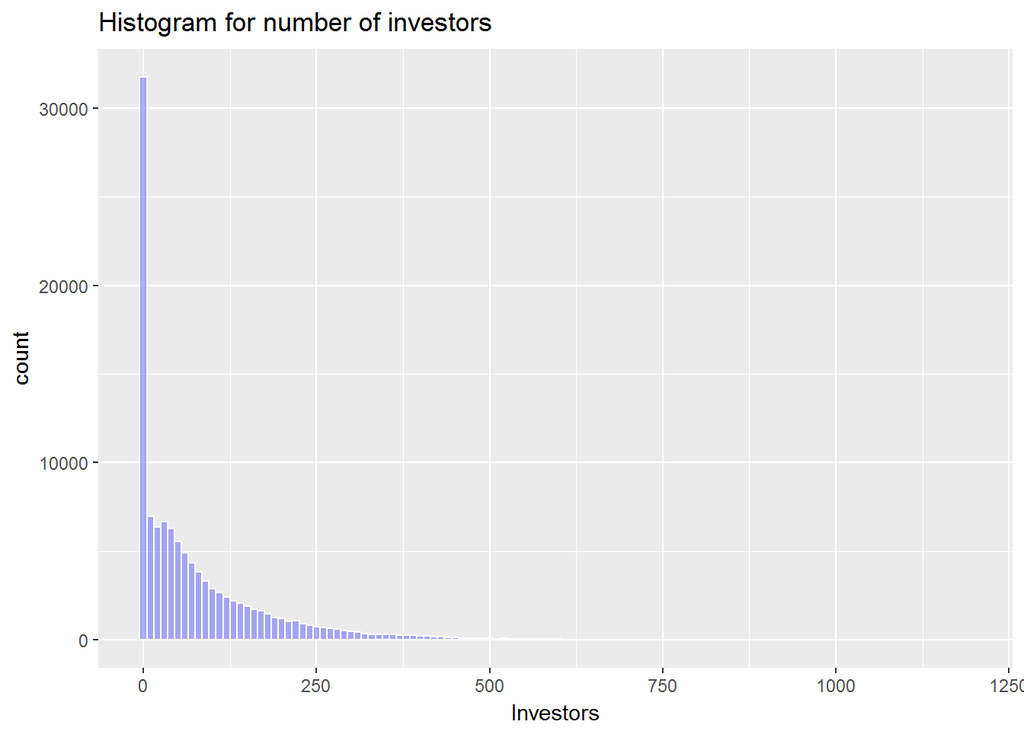

This histogram shows the loan amount. From the histogram we can see a few peaks. Many loans are centered around bins in 4000, 5000, 10000, 15000, 20000 and 25000.

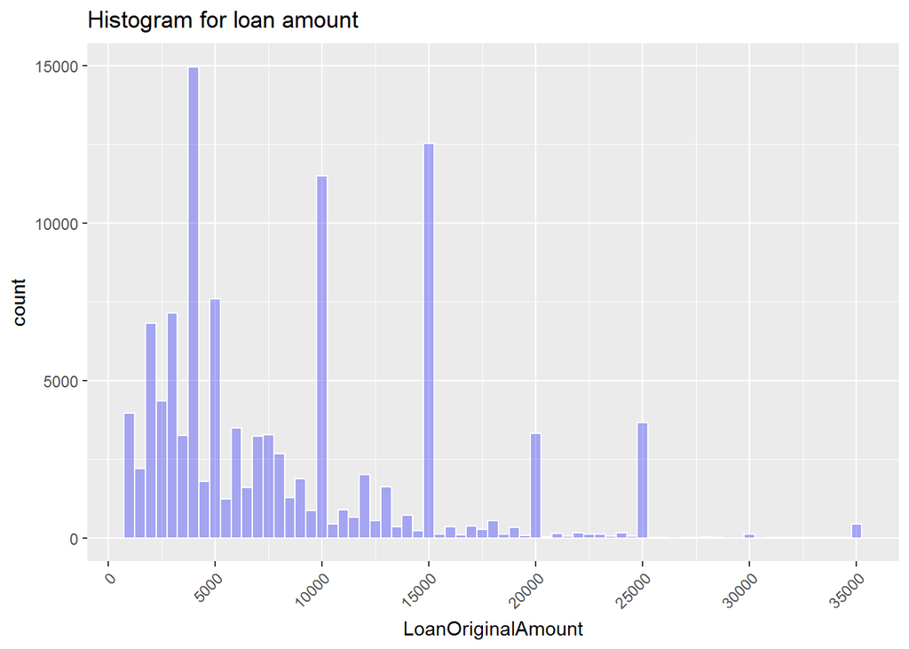

# Bivariate Plots Section

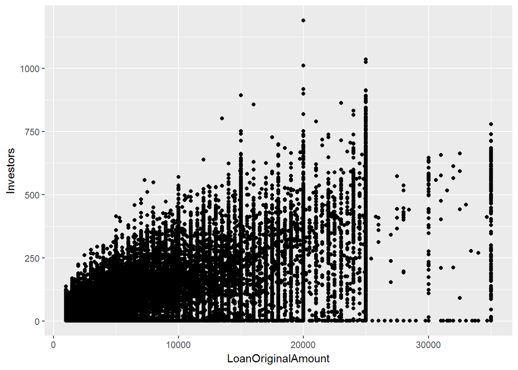

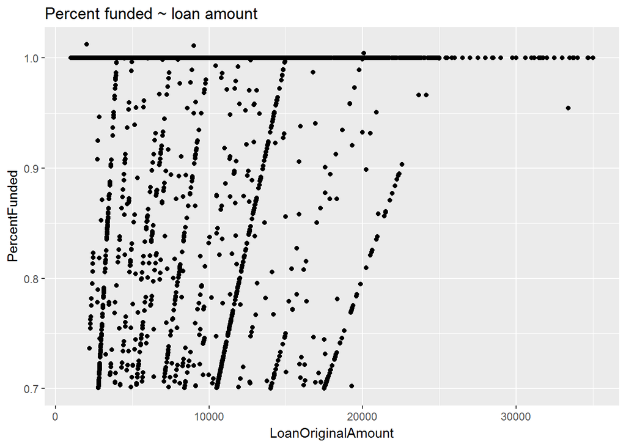

[figure not shown]

```r
cor(df.loan.subset$LoanOriginalAmount, df.loan.subset$Investors)
```

```
## [1] 0.3800926
```

```r
cor(df.loan.subset$LoanOriginalAmount, df.loan.subset$BorrowerRate)
```

```
## [1] -0.3289599
```

# Bivariate Analysis

### Talk about some of the relationships you observed in this part of the investigation. How did the feature(s) of interest vary with other features in the dataset?

### Did you observe any interesting relationships between the other features (not the main feature(s) of interest)?

### What was the strongest relationship you found?

# Multivariate Plots Section

# Multivariate Analysis

### Talk about some of the relationships you observed in this part of the investigation. Were there features that strengthened each other in terms of looking at your feature(s) of interest?

### Were there any interesting or surprising interactions between features?

### OPTIONAL: Did you create any models with your dataset? Discuss the strengths and limitations of your model.

# Final Plots and Summary

# Reflection